# Homework 3

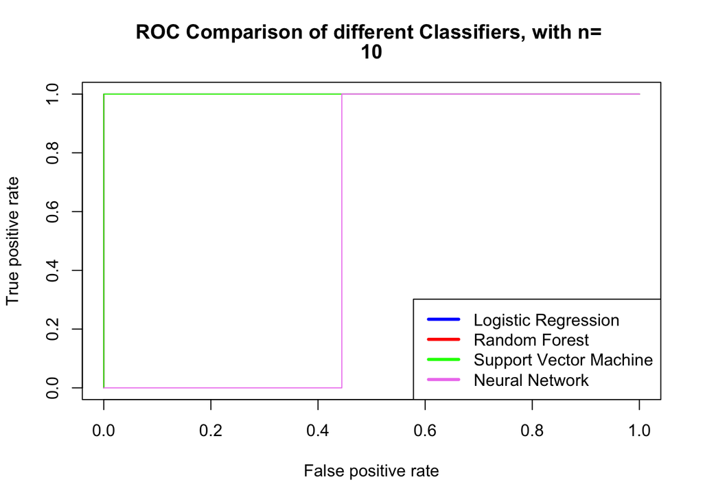

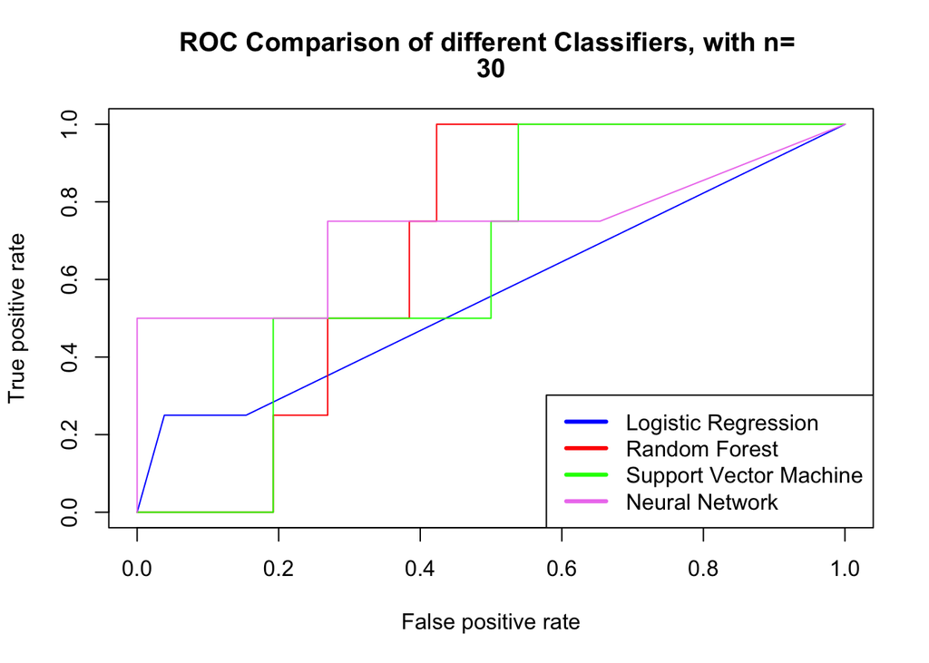

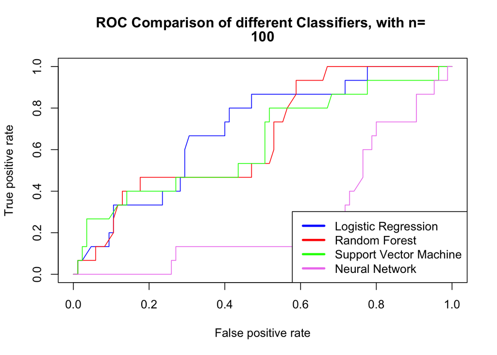

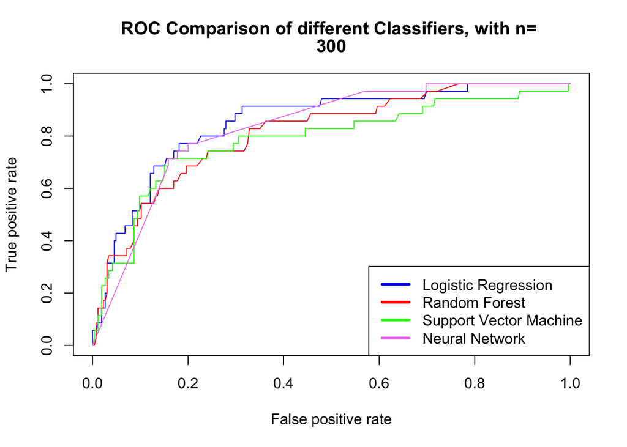

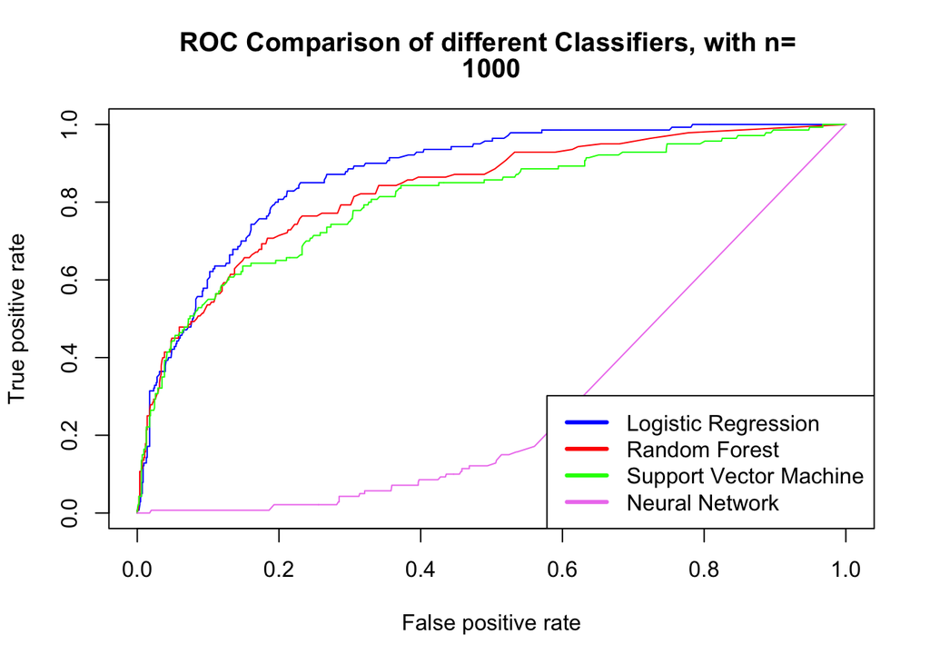

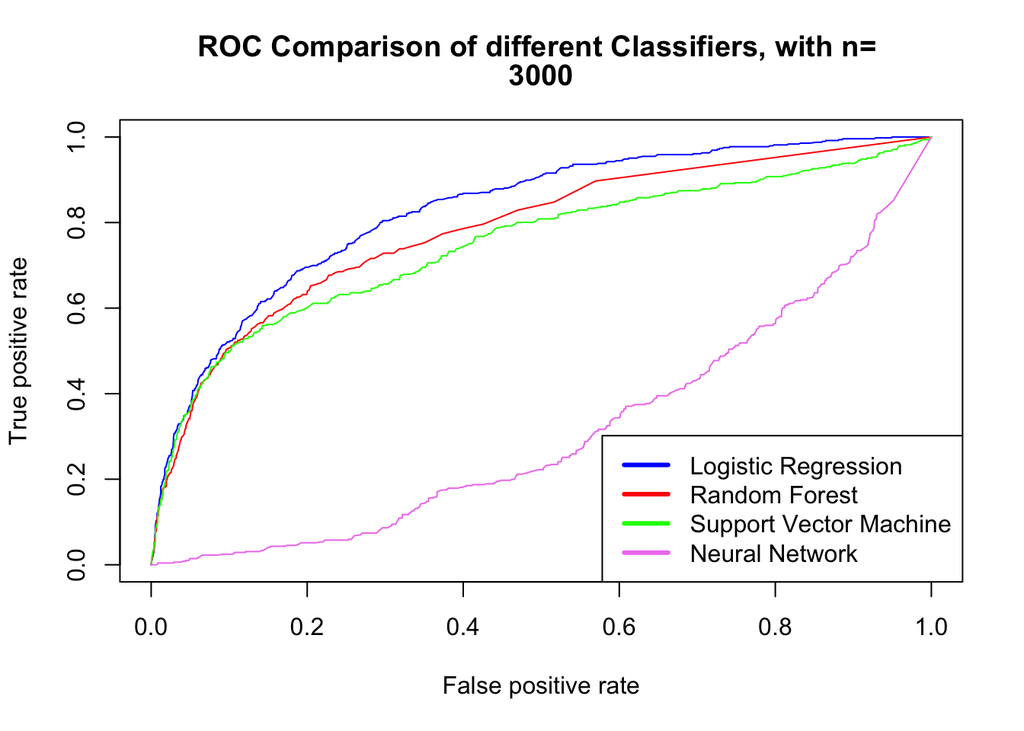

```r
cases = c(10,30,100,300,1000,3000)
plot_comparison = function(size){
  plot(LRROC, col="blue")
  plot(RFROC, add = TRUE, col="red")
  plot(SVMROC, add = TRUE, col="green")
  plot(NNROC, add = TRUE, col="violet")
  title(main=cbind("ROC Comparison of different Classifiers, with n= ",size))
  legend("bottomright",c("Logistic Regression","Random Forest","Support Vector Machine","Neural Network"),col=c("blue","red", "green","violet"), lwd=3, y.intersp = 1.0)
}


for (i in cases) {
  library(neuralnet)
  detach(package:neuralnet) #Killing the ROC prediction function...
  library(ROCR)

  statin_sample = get_data(i,m)
  statin_test = get_data(i,m)
  while(sum(statin_test$mi)==0 || sum(statin_sample$mi)==0) {
    statin_sample = get_data(i,m)
    statin_test = get_data(i,m)
  }

  ##Logistic Regression
  LR <- glm(formula = mi  ~ .,
            family=binomial(link="logit"),data = statin_sample, control = list(maxit = 100))
  LRPredictedProbabilities <- predict(LR, statin_test, type="response")
  LRPred <- prediction(LRPredictedProbabilities, statin_test$mi)
  LRROC <- performance(LRPred,"tpr","fpr")

  ##Random Forests
  library(randomForest)
  RF = randomForest(as.factor(mi==1) ~ ., statin_sample)
  RFPredictedProbabilities = predict(RF,statin_test, type="prob")
  RFPred <- prediction(RFPredictedProbabilities[,2], statin_test$mi)
  RFROC <- performance(RFPred,"tpr","fpr")

  ##Neural Networks
  library(neuralnet)
  n = names(statin_sample)[-11]
  rhs = paste(names(statin_sample[-11]), collapse = " + ")
  formulaString = as.formula(paste0("mi~",rhs))
  #nnSpectTrain = statin_sample %>% mutate_all((function(x) (x-mean(x))/sd(x)))
  #nnSpectTest = statin_test %>% mutate_all(function(x) (x-mean(x))/sd(x))
  NN = neuralnet(formula = formulaString,
                 data = statin_sample,#nnSpectTrain %>% mutate(mi=ifelse(mi>mean(mi),1,0)),
                 err.fct="ce",
                 act.fct="logistic",
                 linear.output = F,
                 hidden=c(1,2), # had to decrease since not converging
                 rep = 5,
                 stepmax=1e5)# takes a bit longer to converge :D
  NNPrdictedProbabilites = compute(NN,statin_test %>% select(-mi))$net.result
  detach(package:neuralnet) #Killing the ROC prediction function...
  library(ROCR)

  NNPred <- prediction(NNPrdictedProbabilites, statin_test$mi)
  NNROC <- performance(NNPred,"tpr","fpr")


  ##SVM
  library(e1071)
  SVM = svm(mi ~ . , statin_sample)

  SVMPredictedProbabilities = predict(SVM, statin_test, type="prob")
  SVMPred <- prediction(SVMPredictedProbabilities, statin_test$mi)
  SVMROC <- performance(SVMPred,"tpr","fpr")

  ##Plotting


plot_comparison(i)

}
```

## Part 3: Survival Analysis (4 points)

Conduct survival analysis. For this we will use the “mgus” data set from `library(survival); mgus`. MGUS is “monogammopathy of unknown significance”, and it is a medical condition identified in asymptomatic individuals who receive blood tests. In some cases it can be a precursor to the blood cancer called multiple myeloma. For more information on the study, see: http://www.mayoclinicproceedings.org/article/S0025-6196(12)60015-9/pdf

Use glm and glmnet to conduct survival analysis with and without regularization. Describe the task and plot a Kaplan Meier curve; conduct your analysis; interpret your findings.

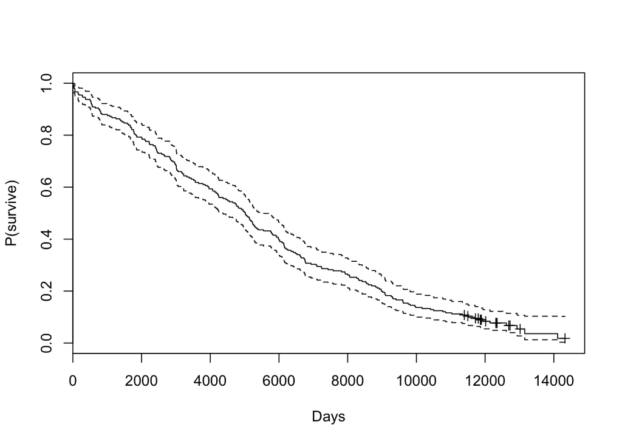

```r
library(survival)
survivalData = mgus %>% tbl_df()

KM = Surv(survivalData$futime, survivalData$death==1) %>%
  (function(x) survfit(x ~ 1, data=survivalData))(.)
# KM curve
plot(KM, xlab= "Days",ylab="P(survive)", mark.time=T)
```

```r
# Cox Model
CM = Surv(survivalData$futime, survivalData$death==1) %>%
  (function(x) coxph(x ~  age  +  sex + dxyr + pcdx +alb + creat +  hgb + mspike , data=survivalData))(.)

"---------------------------"
```

```
## [1] "---------------------------"
```

```r
"Coefficients of Cox Model: "
```

```
## [1] "Coefficients of Cox Model: "
```

```r
"---------------------------"
```

```
## [1] "---------------------------"
```

```r
coef(CM)
```

```
##            age        sexmale           dxyr         pcdxLP         pcdxMA
##  0.08863346679  0.74401587739  0.06826372793 -0.18245583180 -0.17829880505
##         pcdxMM            alb          creat            hgb         mspike
## -0.52307129650  0.14067604458 -0.49930174243  0.05475469145  0.55783207305
```

```r
# Reg Cox Model
library(glmnet)
survivalData["sex"] = ifelse(survivalData["sex"]=="male",1,0)
survivalData["pcdx"] = ifelse(survivalData["pcdx"]=="AM",1,0)
survivalData=survivalData %>% na.omit()
RCM = survivalData  %>%
  (function(x) glmnet(x %>% select(-id,-futime,-pctime,-death) %>%
                        as.data.frame() %>% as.matrix(),
                      Surv(survivalData$futime, survivalData$death==1),
                      family="cox"))(.)
"--------------------------------------"
```

```
## [1] "--------------------------------------"
```

```r
"Coefficients of Regularized Cox Model: "
```

```
## [1] "Coefficients of Regularized Cox Model: "
```

```r
"--------------------------------------"
```

```
## [1] "--------------------------------------"
```

```r
coef(RCM, s=0.05)
```

```
## 8 x 1 sparse Matrix of class "dgCMatrix"
##                     1
## age    0.066923876968
## sex    0.458268327465
## dxyr   0.034945518220
## pcdx   0.407573725242
## alb    0.035002733820
## creat  .
## hgb    0.009598855587
## mspike 0.227792433209
```

*From both calculated Cox Models we can derive that the gender of the patient seems to have the strongest influence on the time to mortality. In the non-regularized model, the size of the monoclonal protien spike at diagnosis (mspike) appears to be also predictive, meanwhile it is not as important in the regularized model. The subtype of plasma cell malignancy specification (pcdx), is also important within both models.* *By analyzing the Kaplan-Meier curve, we can see that the probability to survive almost linearly decreases, which could be an indicator for relatively small chances to die due to MGUS. Especially considering the average age, which is quite high (around 60), increases the probability of other reasons for death within the next years (5000 days = 13.7 years).*